# Tumor type association with latent variable correlated viper protein expression in NF tumors

Robert Allaway

2019-12-13

# Import packages

First, import packages to process and plot the data.

```r
library(dplyr)
library(tidyr)
library(purrr)
library(synapser)
synLogin()
```

```
## Welcome, Robert Allaway!
```

```r
library(clusterProfiler)

viper_res <- synTableQuery('SELECT * FROM syn21260871 where numSamps = 77')$filepath %>% readr::read_csv()
```

[output not shown]

```r
drug_targets <- feather::read_feather(synGet('syn20700199')$path)

drug_targets <- drug_targets %>%
  filter(mean_pchembl > 7) %>%
  mutate(gene= hugo_gene) %>%
  select(gene, std_name)
```

# Significance testing

Then, we’ll select the viper proteins that are 0.65 or greater correlation with latent variable expression, by latent variable (so each group of genes is based on a single latent variable expression, where each gene in the group is a highly-correlated viper protein)- this is basd on the threshold in notebook 16.

Then, we’ll perform a weighted Kolmogorov-Smirnov test using the `GSEA` function from the `clusterProfiler` package to assess whether any of the viper genes are enriched in the universe of druggable genes. Here, we’re treating each LV as the ranked list of viper genes (for standard GSEA, this would be the differentially expressed genes, for example) and treating the list of all drug targets as the gene set we’re looking for enrichment in.

```r
term2gene <- drug_targets %>%
  mutate(term = 'all_drugs') %>%
  select(term, gene) %>%
  distinct()

tidy <- viper_res %>%
  group_by(latent_var) %>%
  filter(corVal > 0.65) %>% #only positively correlated genes >0.65 or so...this is arbitrary
  filter(any(gene %in% term2gene$gene)) %>% ##remove LVs that have no overlap if any exist
  nest() %>%
  mutate(data = lapply(data, function(x){
    geneList <- x$corVal
    names(geneList) <- as.character(x$gene)
    geneList <- sort(geneList, decreasing = TRUE)
    geneList
  })) ##nest gene lists, looking at top 5% of genes in each LV

tidy_2 <- tidy %>% ###run GSEA on nested gene lists vs universe of "druggable genes"
  mutate(data = sapply(data, function(x){
   tryCatch(GSEA(geneList = x, TERM2GENE = term2gene), error=function(err) NA)
 }))

tidy_3 <- tidy_2 %>%  ##store plots and data frames for LVs with significant results
  mutate(plot = lapply(data, function(x){
    if(nrow(x)>0){
      plot <- gseaplot(x, geneSetID = 1)
    }else{
        plot <- NA
    }
    return(plot)
    })) %>%
    mutate(res = lapply(data, function(x){
    if(nrow(x)>0){
      res <- x@result
    }else{
        res <- NA
    }
    return(res)
    }))

tidy_filt <- tidy_3 %>%
  filter(!is.na(plot)) %>%
  select(-data)
```

Then we simply look for LVs where we got a significant (unadjusted) result, and then plot the results. There are 3 LVs significantly enriched for drug targets (again, when considering the 95th percentile of genes in the LV).

Here’s a table of all results. p.adjust shows nothing as being significantly enriched, but I don’t know enough about how the `GSEA` function does the p-value calculation to know if this makes much sense in this context. E.g. it’s pretty clear that there are many druggable targets in each of the LVs in the table (see plots further down), but after adjustment nothing is signficant. One possibility is that the “gene set” of druggable targets is too large at about ~1500 genes?

```r
apply(tidy_filt, 1 , function(x){

  res <- x[['res']] %>%  #we need to fix p.adj because of the way this was run
    mutate(p.adjust = p.adjust(pvalue, n = nrow(tidy))) %>%
    mutate(lv = x[['latent_var']]) %>%
    select(lv,setSize, enrichmentScore, NES,pvalue,p.adjust,
           leading_edge, core_enrichment)

  res

}) %>% bind_rows() %>% DT::datatable()
```

|  | lv | setSize | enrichmentScore | NES | pvalue | p.adjust | leading_edge | core_enrichment |
| --- | --- | --- | --- | --- | --- | --- | --- | --- |
| 1 | LV 303 | 69 | -0.177671078751398 | -1.77596612178049 | 0.0258064516129032 | 1 | tags=83%, list=65%, signal=32% | TRPV1/BRPF1/TYK2/P2RY4/KMT2A/ESR2/CHRM5/DOT1L/KCNH3/KDM5C/KD…… |
| 2 | LV 380 | 83 | -0.157415028345948 | -1.69217485467674 | 0.0275862068965517 | 1 | tags=59%, list=43%, signal=38% | CSNK1D/ITGA2B/ALK/GABBR1/CHRM5/MAP4K2/SMURF1/CREBBP/SPHK2/IG…… |
| 3 | LV 839 | 27 | 0.309388281658533 | 1.66887328878017 | 0.0309446254071661 | 1 | tags=63%, list=39%, signal=46% | FPR1/PDK3/MAP2K1/GPR84/C5AR1/MCHR1/GRB2/ICAM1/FPR2/TLR2/HIF1A/VCP/NCSTN/CSF1R/C3AR1/CCL2/ITGA5 |

Let’s plot these results.

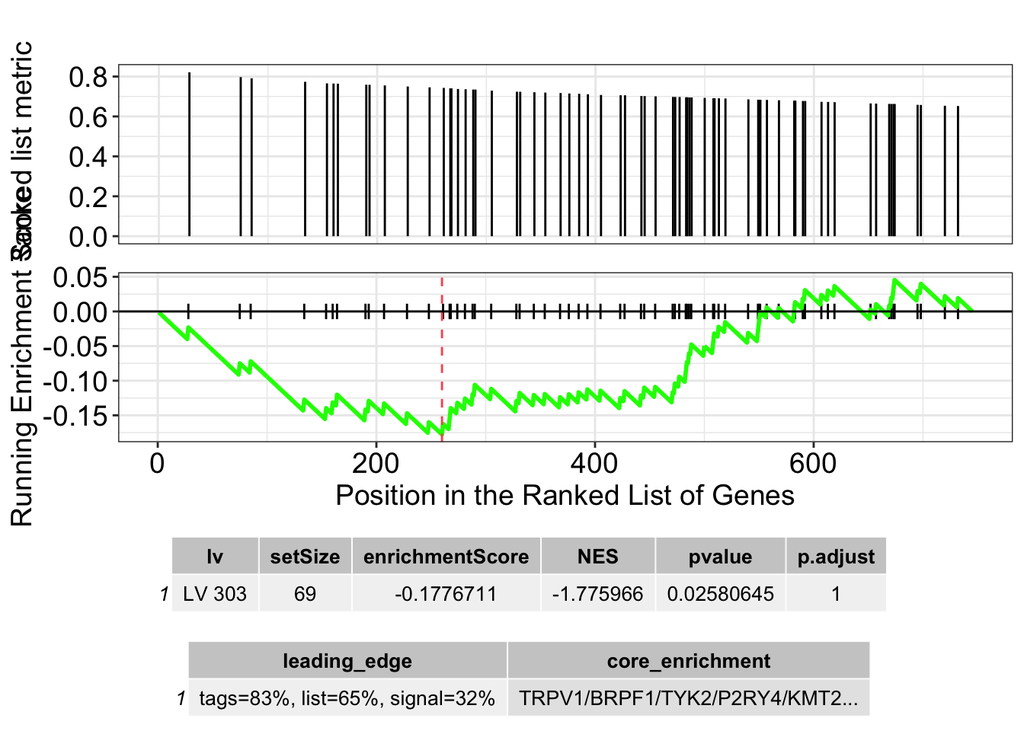

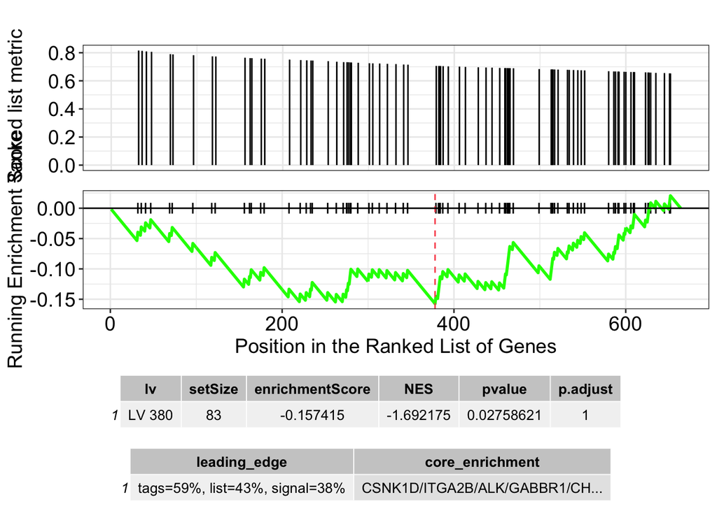

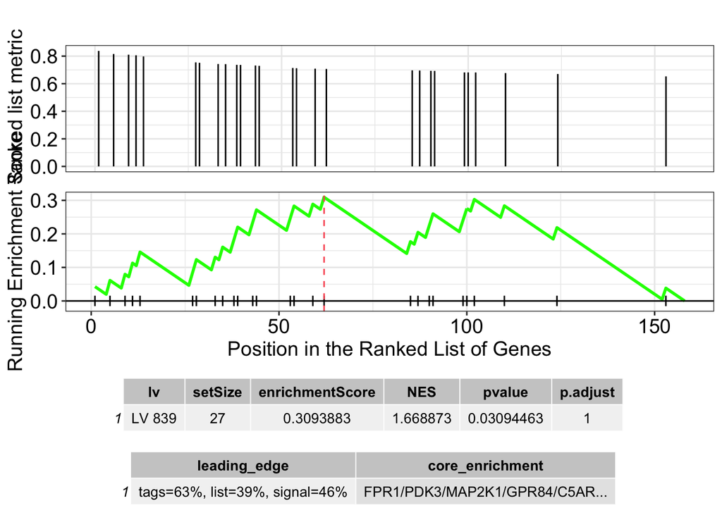

```r
apply(tidy_filt, 1, function(x){

  plt <- x[['plot']]

  res <- x[['res']] %>%  #we need to fix p.adj because of the way this was run
    mutate(p.adjust = p.adjust(pvalue, n = nrow(tidy))) %>%
    mutate(lv = x[['latent_var']])

  tab_1 <- select(res,lv,setSize, enrichmentScore, NES,pvalue,p.adjust) %>%
    ggpubr::ggtexttable(theme = ggpubr::ttheme(base_size = 10))

  tab_2 <- select(res,leading_edge, core_enrichment) %>%
    mutate(core_enrichment = stringr::str_trunc(core_enrichment, width = 30)) %>%
    ggpubr::ggtexttable(theme = ggpubr::ttheme(base_size = 10))

   cowplot::plot_grid(plt, tab_1, tab_2, nrow=3,ncol=1, rel_heights = c(5,1,1))
})
```

Here are the highly correlated viper proteins for each of the above LVs. I think that GSEA might be too “aggressive” of a test for this - we don’t really care so much if there are *many* druggable genes in each set of viper proteins, just that there are some or even one highly ranked in the list of correlated viper proteins.

```r
apply(tidy_filt, 1, function(x){

  plt <- x[['plot']]

  res <- x[['res']] %>%  #we need to fix p.adj because of the way this was run
    mutate(p.adjust = p.adjust(pvalue, n = nrow(tidy))) %>%
    mutate(lv = x[['latent_var']])

  viper_res %>%
    filter(latent_var %in% res$lv) %>%
    filter(corVal > 0.65) %>%
    filter(gene %in% term2gene$gene)

  # cowplot::plot_grid(plt, tab_1, tab_2,tab_3, nrow=4,ncol=1, rel_heights = c(5,1,1))
})
```

```
## [[1]]
## # A tibble: 69 x 6
##    ROW_ID ROW_VERSION latent_var gene   corVal numSamps
##     <dbl>       <dbl> <chr>      <chr>   <dbl>    <dbl>
##  1 785877         116 LV 303     ABL1    0.673       77
##  2 785969         116 LV 303     ADRA2B  0.755       77
##  3 786033         116 LV 303     ALK     0.664       77
##  4 786256         116 LV 303     ATM     0.673       77
##  5 786266         116 LV 303     ATR     0.663       77
##  6 786279         116 LV 303     AVPR1B  0.698       77
##  7 786382         116 LV 303     BRD4    0.691       77
##  8 786389         116 LV 303     BRPF1   0.741       77
##  9 786391         116 LV 303     BRSK1   0.821       77
## 10 786439         116 LV 303     CAMKK2  0.684       77
## # … with 59 more rows
##
## [[2]]
## # A tibble: 83 x 6
##    ROW_ID ROW_VERSION latent_var gene     corVal numSamps
##     <dbl>       <dbl> <chr>      <chr>     <dbl>    <dbl>
##  1 840705         124 LV 380     ABL1      0.678       77
##  2 840729         124 LV 380     ACVR1B    0.690       77
##  3 840857         124 LV 380     AKT2      0.674       77
##  4 840861         124 LV 380     ALK       0.705       77
##  5 841107         124 LV 380     AVPR1B    0.669       77
##  6 841210         124 LV 380     BRD4      0.757       77
##  7 841217         124 LV 380     BRPF1     0.788       77
##  8 841219         124 LV 380     BRSK1     0.690       77
##  9 841267         124 LV 380     CAMKK2    0.740       77
## 10 841423         124 LV 380     CDC42BPB  0.680       77
## # … with 73 more rows
##
## [[3]]
## # A tibble: 27 x 6
##     ROW_ID ROW_VERSION latent_var gene   corVal numSamps
##      <dbl>       <dbl> <chr>      <chr>   <dbl>    <dbl>
##  1 1139746         165 LV 839     C3AR1   0.712       77
##  2 1139747         165 LV 839     C5AR1   0.798       77
##  3 1139846         165 LV 839     CCL2    0.709       77
##  4 1140166         165 LV 839     CSF1R   0.714       77
##  5 1140210         165 LV 839     CXCR4   0.653       77
##  6 1140737         165 LV 839     FPR1    0.838       77
##  7 1140738         165 LV 839     FPR2    0.742       77
##  8 1140954         165 LV 839     GPR183  0.694       77
##  9 1140986         165 LV 839     GPR84   0.806       77
## 10 1141008         165 LV 839     GRB2    0.752       77
## # … with 17 more rows
```